# Dots + interval stats and geoms

## On discrete distributions

The dots family includes a variety of features to make visualizing discrete and categorical distributions easier. These distributions can be hard to visualize under the default settings if the dots become very small:

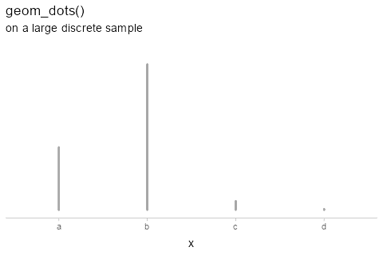

```r
set.seed(1234)
abcd_df = tibble(
  x = sample(c("a", "b", "c", "d"), 1000, replace = TRUE, prob = c(0.27, 0.6, 0.03, 0.005)),
  g = rep(c("a","b"), 500)
)

abcd_df %>%
  ggplot(aes(x = x)) +
  geom_dots() +
  scale_y_continuous(breaks = NULL) +
  labs(
    title = "geom_dots()",
    subtitle = "on a large discrete sample"
  )
```

The automatic bin width algorithm selects a dot size that is very small in order to ensure the tallest bin fits in the plot, but this means the dots are hard to see.

Bar-like layouts can be achieved by using `layout = "bar"`:

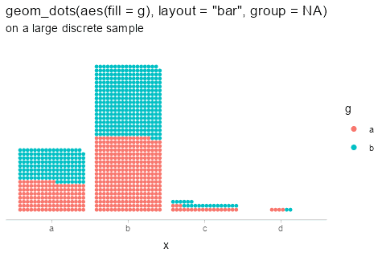

```r
abcd_df %>%
  ggplot(aes(x = x, fill = g, order = g)) +
  geom_dots(layout = "bar", group = NA, color = NA) +
  scale_y_continuous(breaks = NULL) +
  labs(
    title = 'geom_dots(aes(fill = g), layout = "bar", group = NA)',
    subtitle = "on a large discrete sample"
  )
```

Notice how we set `group = NA` to override the default `ggplot2` behavior of grouping data by all discrete variables. This allows the layout to be calculated taking all groups into account.

We can also use the `smooth` parameter to improve the display of discrete distributions, for which `geom_dots()` supports a handful of *smoothers*. These all correspond to functions that start with `smooth_`, like `smooth_bounded()`, `smooth_unbounded()`, and `smooth_discrete()`, and can be applied either by passing the suffix as a string (e.g. `smooth = "bounded"`) or by passing the function itself, to set specific options on it (e.g. `smooth = smooth_bounded(adjust = 0.5)`).

`smooth_discrete()` applies a kernel density smoother whose default bandwidth is less than the distances between bins. We can use the `kernel` argument (passed to `density_bounded()`; the same kernels from `stats::density()` are available) to change the shape of the bins.

For example, using the `"epanechnikov"` (parabolic) kernel along with `side = "both"`, we can create lozenge-like shapes. We’ll abbreviate the kernel `"ep"` to save typing out `"epanechnikov"` (partial matching is allowed):

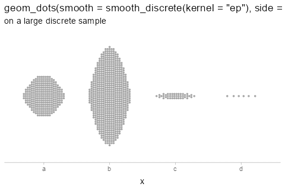

```r
abcd_df %>%
  ggplot(aes(x = x)) +
  geom_dots(smooth = smooth_discrete(kernel = "ep"), side = "both") +
  scale_y_continuous(breaks = NULL) +
  labs(
    title = 'geom_dots(smooth = smooth_discrete(kernel = "ep"), side = "both")',
    subtitle = "on a large discrete sample"
  )
```

## On analytical distributions

Like the `stat_slabinterval()` family, `stat_dotsinterval()` and `stat_dots()` support using both sample data (via `x` and `y` aesthetics) or analytical distributions (via the `xdist` and `ydist` aesthetics). For analytical distributions, these stats accept specifications for distributions in one of two ways:

1. **Using distribution names as character vectors**: this format uses aesthetics as follows:
   - `xdist`, `ydist`, or `dist`: the name of the distribution, following R’s naming scheme. This is a string which should have `"p"`, `"q"`, and `"d"` functions defined for it: e.g., “norm” is a valid distribution name because the `pnorm()`, `qnorm()`, and `dnorm()` functions define the CDF, quantile function, and density function of the Normal distribution.
   - `args` or `arg1`, … `arg9`: arguments for the distribution. If you use `args`, it should be a list column where each element is a list containing arguments for the distribution functions; alternatively, you can pass the arguments directly using `arg1`, … `arg9`.
2. **Using distribution vectors from the [distributional](https://pkg.mitchelloharawild.com/distributional/) package or `posterior::rvar()` objects**: this format uses aesthetics as follows:
   - `xdist`, `ydist`, or `dist`: a distribution vector or `posterior::rvar()` produced by functions such as `distributional::dist_normal()`, `distributional::dist_beta()`, `posterior::rvar_rng()`, etc.

For example, here are a variety of distributions:

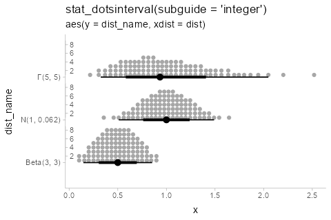

```r
dist_df = tibble(
  dist = c(dist_normal(1,0.25), dist_beta(3,3), dist_gamma(5,5)),
  dist_name = format(dist)
)

dist_df %>%
  ggplot(aes(y = dist_name, xdist = dist)) +
  stat_dotsinterval(subguide = 'integer') +
  ggtitle(
    "stat_dotsinterval(subguide = 'integer')",
    "aes(y = dist_name, xdist = dist)"
  )
```

This example also shows the use of sub-guides to label dot counts. See the documentation of `subguide_axis()` and its shortcuts (particularly `subguide_integer()` and `subguide_count()`) for more examples.

Analytical distributions are shown by default using 100 quantiles, sometimes referred to as a *quantile dotplot*, which can help people make better decisions under uncertainty ([Kay 2016](https://doi.org/10.1145/2858036.2858558), [Fernandes 2018](https://doi.org/10.1145/3173574.3173718)). This can be changed using the `quantiles` argument. For example, we can plot the same distributions again using 1000 quantiles. We’ll also make use of `point_interval` to plot the mode and highest-density continuous intervals (instead of the default median and quantile intervals; see `point_interval()`).

We’ll also highlight some intervals by coloring the dots. Like with the `stat_slabinterval()` family, computed variables from the interval sub-geometry (`level` and `.width`) are available to the dots/slab sub-geometry, and correspond to the smallest interval containing that dot. We can use these to color dots according to the interval containing them (we’ll also use the `"weave"` layout since it maintains x positions better than the `"bin"` layout):

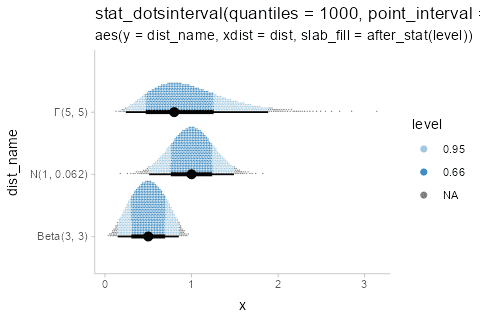

```r
dist_df %>%
  ggplot(aes(y = dist_name, xdist = dist, slab_fill = after_stat(level))) +
  stat_dotsinterval(quantiles = 1000, point_interval = mode_hdci, layout = "weave", slab_color = NA) +
  scale_color_manual(values = scales::brewer_pal()(3)[-1], aesthetics = "slab_fill") +
  ggtitle(
    "stat_dotsinterval(quantiles = 1000, point_interval = mode_hdci)",
    "aes(y = dist_name, xdist = dist, slab_fill = after_stat(level))"
  )
```

When summarizing sample distributions with `stat_dots()`/`stat_dotsinterval()` (e.g. samples from Bayesian posteriors), one can also use the `quantiles` argument, though it is not on by default.

### Varying continuous aesthetics with analytical distributions

While varying discrete aesthetics works similarly with `stat_dotsinterval()`/`stat_dots()` as it does with `geom_dotsinterval()`/`geom_dots()`, varying continuous aesthetics within dot groups typically requires mapping the continuous aesthetic *after* the stats are computed. This is because the stat (at least for analytical distributions) must first generate the quantiles before properties of those quantiles can be mapped to aesthetics.

Thus, because it relies upon generated variables from the stat, you can use the `after_stat()` or `stage()` functions from `ggplot2` to map those variables. For example:

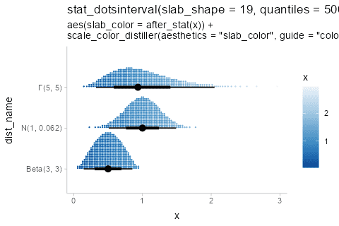

```r
dist_df %>%
  ggplot(aes(y = dist_name, xdist = dist, slab_color = after_stat(x))) +
  stat_dotsinterval(slab_shape = 19, quantiles = 500) +
  scale_color_distiller(aesthetics = "slab_color", guide = "colorbar2") +
  ggtitle(
    "stat_dotsinterval(slab_shape = 19, quantiles = 500)",
    'aes(slab_color = after_stat(x)) +\nscale_color_distiller(aesthetics = "slab_color", guide = "colorbar2")'
  )
```

This example also demonstrates the use of sub-geometry scales: the `slab_`-prefixed aesthetics `slab_color` and `slab_shape` must be used to target the color and shape of the slab (“slab” here refers to the stack of dots) when using `geom_dotsinterval()` and `stat_dotsinterval()` to disambiguate between the point/interval and the dot stack. When using `stat_dots()`/`geom_dots()` this is not necessary.

Also note the use of `scale_color_distiller()`, a base ggplot2 color scale, with the `slab_color` aesthetic by setting the `aesthetics` and `guide` properties (the latter is necessary because the default `guide = "colorbar"` will not work with non-standard color aesthetics).

### Thresholds

Another potentially useful application of post-stat aesthetic computation is to apply thresholds on a dotplot, coloring points on one side of a line differently. However, the default dotplot layout, `"bin"`, can cause dots to be on the wrong side of a cutoff when coloring dots within dotplots. Thus it can be useful when plotting thresholds to use the `"weave"` or `"swarm"` layouts, which tend to position dots closer to their true `x` positions, rather than at bin centers:

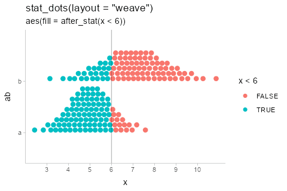

```r
ab_df = tibble(
  ab = c("a", "b"),
  mean = c(5, 7),
  sd = c(1, 1.5)
)

ab_df %>%
  ggplot(aes(y = ab, xdist = dist_normal(mean, sd), fill = after_stat(x < 6))) +
  stat_dots(position = "dodge", color = NA, layout = "weave") +
  labs(
    title = 'stat_dots(layout = "weave")',
    subtitle = "aes(fill = after_stat(x < 6))"
  ) +
  geom_vline(xintercept = 6, alpha = 0.25) +
  scale_x_continuous(breaks = 2:10)
```

## Rain cloud plots

Sometimes you may want to include multiple different types of slabs in the same plot in order to take advantage of the features each slab type provides. For example, people often combine densities with dotplots to show the underlying datapoints that go into a density estimate, creating so-called *rain cloud* plots.

To use multiple slab geometries together, you can use the `side` parameter to change which side of the interval a slab is drawn on and set the `scale` parameter to something around `0.5` (by default it is `0.9`) so that the two slabs do not overlap. We’ll also scale the halfeye slab thickness by `n` (the number of observations in each group) so that the area of each slab represents sample size (and looks similar to the total area of its corresponding dotplot).

We’ll use a subsample of of the data to show how it might look on a reasonably-sized dataset.

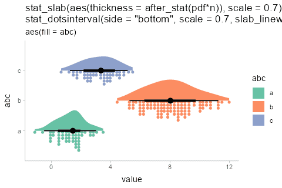

```r
set.seed(12345) # for reproducibility

tibble(
  abc = rep(c("a", "b", "b", "c"), 50),
  value = rnorm(200, c(1, 8, 8, 3), c(1, 1.5, 1.5, 1))
) %>%
  ggplot(aes(y = abc, x = value, fill = abc)) +
  stat_slab(aes(thickness = after_stat(pdf*n)), scale = 0.7) +
  stat_dotsinterval(side = "bottom", scale = 0.7, slab_linewidth = NA) +
  scale_fill_brewer(palette = "Set2") +
  ggtitle(
    paste0(
      'stat_slab(aes(thickness = after_stat(pdf*n)), scale = 0.7) +\n',
      'stat_dotsinterval(side = "bottom", scale = 0.7, slab_linewidth = NA)'
    ),
    'aes(fill = abc)'
  )
```

## Dotplots with Monte Carlo Standard Error

A specialized variant of `geom_dots()`, `geom_blur_dots()`, supports visualizing dotplots with blur applied to each dot. `stat_mcse_dots()` uses `geom_blur_dots()` with `posterior::mcse_quantile()` to show the error in each quantile of a quantile dotplot:

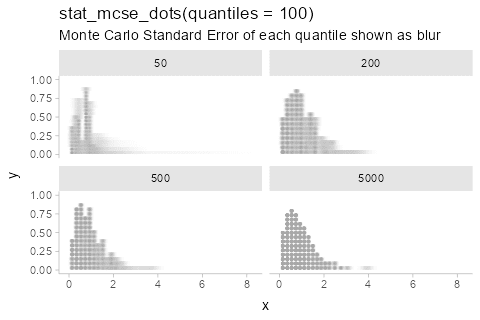

```r
increasing_samples %>%
  ggplot(aes(x = x)) +
  stat_mcse_dots(quantiles = 100) +
  facet_wrap(~ n) +
  labs(
    title = "stat_mcse_dots(quantiles = 100)",
    subtitle = "Monte Carlo Standard Error of each quantile shown as blur"
  )
```

Custom blur functions can be selected using the `blur` parameter, including the built-in `blur_interval()`, which draws an interval with a default width of 95%:

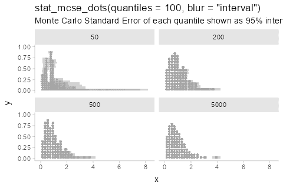

```r
increasing_samples %>%
  ggplot(aes(x = x)) +
  stat_mcse_dots(quantiles = 100, blur = "interval") +
  facet_wrap(~ n) +
  labs(
    title = 'stat_mcse_dots(quantiles = 100, blur = "interval")',
    subtitle = "Monte Carlo Standard Error of each quantile shown as 95% intervals"
  )
```

## Logit dotplots

To demonstrate another useful plot type, the *logit dotplot* (courtesy [Ladislas Nalborczyk](https://lnalborczyk.github.io/post/glm/)), we’ll fit a logistic regression to some data on the petal length of the *Iris versicolor* and *Iris virginica* flowers.

First, we’ll demo varying the `side` aesthetic to create two dotplots that are “facing” each other: `scale_side_mirrored()` will set the `side` aesthetic to `"top"` or `"bottom"` if two categories are assigned to `side`“. We also adjust the `scale` so that the dots don’t overlap:

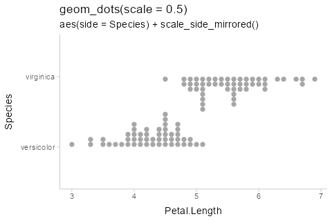

```r
iris_v = iris %>%
  filter(Species != "setosa")

iris_v %>%
  ggplot(aes(x = Petal.Length, y = Species, side = Species)) +
  geom_dots(scale = 0.5) +
  scale_side_mirrored(guide = "none") +
  ggtitle(
    "geom_dots(scale = 0.5)",
    'aes(side = Species) + scale_side_mirrored()'
  )
```

This can also be accomplished by setting side directly and omitting `scale_side_mirrored()`; e.g. via `aes(side = ifelse(Species == "virginica", "bottom", "top"))`.

Now we fit a logistic regression predicting species based on petal length:

```r
m = glm(Species == "virginica" ~ Petal.Length, data = iris_v, family = binomial)
m
```

```
##
## Call:  glm(formula = Species == "virginica" ~ Petal.Length, family = binomial,
##     data = iris_v)
##
## Coefficients:
##  (Intercept)  Petal.Length
##      -43.781         9.002
##
## Degrees of Freedom: 99 Total (i.e. Null);  98 Residual
## Null Deviance:       138.6
## Residual Deviance: 33.43     AIC: 37.43
```

Then we can overlay a fit line as a `stat_lineribbon()` (see `vignette("lineribbon")`) on top of the mirrored dotplots to create a *logit dotplot*:

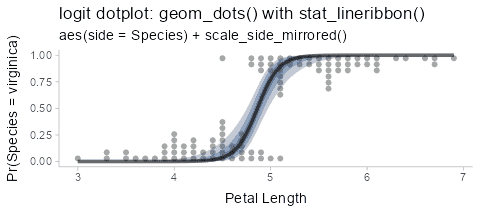

```r
# construct a prediction grid for the fit line
prediction_grid = with(iris_v,
  data.frame(Petal.Length = seq(min(Petal.Length), max(Petal.Length), length.out = 100))
)

prediction_grid %>%
  bind_cols(predict(m, ., se.fit = TRUE)) %>%
  mutate(
    # distribution describing uncertainty in log odds
    log_odds = dist_normal(fit, se.fit),
    # inverse-logit transform the log odds to get
    # distribution describing uncertainty in Pr(Species == "virginica")
    p_virginica = dist_transformed(log_odds, plogis, qlogis)
  ) %>%
  ggplot(aes(x = Petal.Length)) +
  geom_dots(
    aes(y = as.numeric(Species == "virginica"), side = Species),
    scale = 0.4,
    data = iris_v
  ) +
  stat_lineribbon(
    aes(ydist = p_virginica), alpha = 1/4, fill = "#08306b"
  ) +
  scale_side_mirrored(guide = "none") +
  coord_cartesian(ylim = c(0, 1)) +
  labs(
    title = "logit dotplot: geom_dots() with stat_lineribbon()",
    subtitle = 'aes(side = Species) + scale_side_mirrored()',
    x = "Petal Length",
    y = "Pr(Species = virginica)"
  )
```